# Examine `tumor_descriptor` and `experimental_strategy` distributions

ZZGeng

2024-06-03

This notebook is adapted from OpenPBTA (https://github.com/AlexsLemonade/OpenPBTA-analysis/blob/master/analyses/sample-distribution-analysis/03-tumor-descriptor-and-assay-count.Rmd) to investigate the distribution of experimental strategy of OpenPedCan project.

```r
library(tidyverse)
# this library will help display tables with smaller font for easy viewing
# in the HTML setting
library(flextable)
```

## Read in histologies file

```r
root_dir <- rprojroot::find_root(rprojroot::has_dir(".git"))
analysis_dir <- file.path(root_dir, "figures", "manuscript_OPC")
results_dir <- file.path(analysis_dir, "results")
plots_dir <- file.path(analysis_dir, "plots")
```

## read histologies

```r
histology_file <- file.path(root_dir, "data", "histologies.tsv")
histology_df <- readr::read_tsv(histology_file, guess_max = 10000)
```

For WGS and WXS samples, we’ll have tumor and normal to get the somatic calls. We’ll limit this to tumor samples to avoid double-counting participants and we’ll remove derived cell lines.

```r
tumor_df <- histology_df %>%
  filter(sample_type == "Tumor",
         composition == "Solid Tissue")
```

## Number of each assay

First, we’ll examine how many of each type of assay we have (tumors only). This information is stored in the `experimental_strategy` column.

```r
exp_strategy_df <- tumor_df %>%
  group_by(experimental_strategy) %>%
  tally() %>%
  arrange(desc(n))

exp_strategy_df %>%
  regulartable() %>%
  fontsize(size = 12, part = "all")
```

| experimental_strategy | n |
| --- | --- |
| RNA-Seq | 12,296 |
| WGS | 2,828 |
| Methylation | 2,428 |
| Targeted Sequencing | 1,608 |
| WXS | 560 |
| Phospho-Proteomics | 407 |
| Whole Cell Proteomics | 407 |
| miRNA-Seq | 262 |

## generate plot for experimental strategy

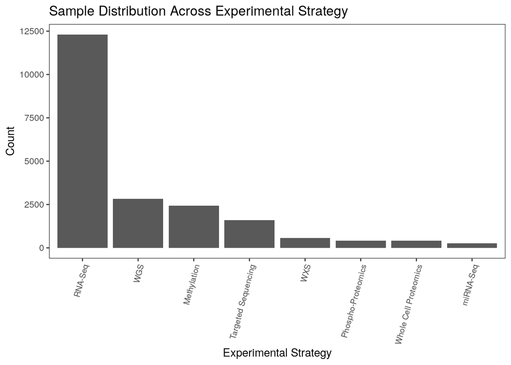

```r
exp_strategy_df %>%
  ggplot2::ggplot(ggplot2::aes(x = factor(experimental_strategy, levels = (experimental_strategy)),
                               y = n)) +
  ggplot2::geom_col() +
  ggplot2::theme_bw() +
  ggplot2::labs(x = "Experimental Strategy", y = "Count",
                title = "Sample Distribution Across Experimental Strategy") +
  ggplot2::theme(axis.text.x = ggplot2::element_text(
    angle = 75,
    hjust = 1,
    size = 8
  ),
  panel.grid = ggplot2::element_blank())
```

```r
ggsave(
  file = file.path(plots_dir, "distribution_across_experimental_strategy.pdf"),
  width = 12,
  height = 10)
```

## Primary vs. other (recurrence, progressive disease)

We’ll look at the breakdown of the `tumor_descriptor` column, separating the genomic assays from transcriptomic assays.

```r
tumor_descriptor_df <- tumor_df %>%
  select(Kids_First_Participant_ID,
         experimental_strategy,
         tumor_descriptor) %>%
  arrange(Kids_First_Participant_ID)
```

### Genomic assays

Setting aside the `Panel` sample for the moment and only looking at WXS and WGS assays. We’re collapsing the different values in `tumor_descriptor` to form a single descriptor when there are multiple types of tumors from the same individual.

```r
genomic_df <- tumor_descriptor_df %>%
  filter(experimental_strategy %in% c("WGS", "WXS")) %>%
  group_by(Kids_First_Participant_ID) %>%
  summarize(descriptors = paste(sort(unique(tumor_descriptor)),
                                collapse = ", "),
            experimental_strategy = paste(sort(unique(experimental_strategy)),
                                          collapse = ", "))
```

```r
genomic_df %>%
  group_by(descriptors) %>%
  tally() %>%
  arrange(desc(n)) %>%
  regulartable() %>%
  fontsize(size = 12, part = "all")
```

| descriptors | n |
| --- | --- |
| Initial CNS Tumor | 1,540 |
| Primary Tumor | 658 |
| Progressive | 165 |
| Recurrence | 160 |
| Deceased | 83 |
| Initial CNS Tumor, Progressive | 57 |
| Initial CNS Tumor, Recurrence | 40 |
| Deceased, Initial CNS Tumor | 29 |
| Second Malignancy | 13 |
| Initial CNS Tumor, Second Malignancy | 8 |
| Initial CNS Tumor, Progressive, Recurrence | 7 |
| Progressive, Recurrence | 7 |
| Primary Tumor, Recurrence | 6 |
| Deceased, Recurrence | 4 |
| Deceased, Initial CNS Tumor, Progressive | 3 |
| Deceased, Initial CNS Tumor, Recurrence | 3 |
| Deceased, Progressive | 3 |
| Deceased, Progressive, Recurrence | 3 |
| Initial CNS Tumor, Progressive Disease Post-Mortem | 3 |
| Recurrence, Second Malignancy | 3 |
| Initial CNS Tumor, Unknown | 2 |
| Metastatic | 2 |
| Residual | 2 |
| Unknown | 2 |
| Deceased, Initial CNS Tumor, Progressive, Recurrence | 1 |
| Deceased, Initial CNS Tumor, Second Malignancy | 1 |
| Deceased, Second Malignancy | 1 |
| Initial CNS Tumor, Progressive, Progressive Disease Post-Mortem | 1 |
| Initial CNS Tumor, Recurrence, Second Malignancy | 1 |
| Progressive, Second Malignancy | 1 |

Only primary samples is the most common case for genomic assays.

### Transcriptomic assays

Looking only at RNA-seq samples and performing the same collapsing of the `tumor_descriptor` column.

```r
transcriptomic_df <- tumor_descriptor_df %>%
  filter(experimental_strategy == "RNA-Seq") %>%
  group_by(Kids_First_Participant_ID) %>%
  summarize(descriptors = paste(sort(unique(tumor_descriptor)),
                                collapse = ", "),
            experimental_strategy = unique(experimental_strategy))
```

```r
transcriptomic_df %>%
  group_by(descriptors) %>%
  tally() %>%
  arrange(desc(n)) %>%
  regulartable() %>%
  fontsize(size = 12, part = "all")
```

| descriptors | n |
| --- | --- |
| Primary Tumor | 9,584 |
| Initial CNS Tumor | 1,314 |
| Metastatic | 365 |
| Recurrence | 165 |
| Progressive | 141 |
| Deceased | 75 |
| Primary Tumor, Recurrence | 43 |
| Initial CNS Tumor, Progressive | 42 |
| Initial CNS Tumor, Recurrence | 30 |
| Metastatic, Primary Tumor | 28 |
| Deceased, Initial CNS Tumor | 22 |
| Second Malignancy | 11 |
| Progressive, Recurrence | 6 |
| Unknown | 5 |
| Deceased, Recurrence | 4 |
| Initial CNS Tumor, Progressive, Recurrence | 4 |
| Initial CNS Tumor, Second Malignancy | 4 |
| Deceased, Progressive, Recurrence | 3 |
| Recurrence, Second Malignancy | 3 |
| Deceased, Second Malignancy | 2 |
| Residual | 2 |
| Deceased, Initial CNS Tumor, Recurrence | 1 |
| Deceased, Progressive | 1 |
| Initial CNS Tumor, Unknown | 1 |

The same holds for RNA-seq.

### Paired genomic, transcriptomic assays

How many participants have paired genomic and transcriptomic samples for the same `tumor_descriptor` values?

```r
# if we perform a full join here using the pariticpant ID and descriptors, we
# will get NAs in columns where pairs don't exist and can use this information
# to count
paired_df <-
  full_join(genomic_df, transcriptomic_df,
                   by = c("Kids_First_Participant_ID", "descriptors"))
```

#### All paired

Count the examples where all time points have both kinds of assays.

```r
# no NAs = both kinds of assays a re present
paired_df %>%
  filter(complete.cases(.)) %>%
  group_by(descriptors) %>%
  tally() %>%
  arrange(desc(n)) %>%
  regulartable() %>%
  fontsize(size = 12, part="all")
```

| descriptors | n |
| --- | --- |
| Initial CNS Tumor | 1,157 |
| Primary Tumor | 390 |
| Recurrence | 129 |
| Progressive | 116 |
| Deceased | 42 |
| Initial CNS Tumor, Progressive | 35 |
| Initial CNS Tumor, Recurrence | 27 |
| Deceased, Initial CNS Tumor | 14 |
| Primary Tumor, Recurrence | 6 |
| Second Malignancy | 5 |
| Deceased, Recurrence | 4 |
| Initial CNS Tumor, Progressive, Recurrence | 4 |
| Progressive, Recurrence | 4 |
| Deceased, Progressive, Recurrence | 3 |
| Initial CNS Tumor, Second Malignancy | 3 |
| Recurrence, Second Malignancy | 3 |
| Residual | 2 |
| Deceased, Initial CNS Tumor, Recurrence | 1 |
| Deceased, Progressive | 1 |
| Deceased, Second Malignancy | 1 |
| Initial CNS Tumor, Unknown | 1 |
| Unknown | 1 |

#### No RNA-seq

If the `experimental_strategy.y` column has an `NA`, RNA-seq is missing for that participant-descriptors pair.

```r
paired_df %>%
  filter(is.na(experimental_strategy.y)) %>%
  group_by(descriptors) %>%
  tally() %>%
  regulartable() %>%
  fontsize(size = 12, part = "all")
```

| descriptors | n |
| --- | --- |
| Deceased | 41 |
| Deceased, Initial CNS Tumor | 15 |
| Deceased, Initial CNS Tumor, Progressive | 3 |
| Deceased, Initial CNS Tumor, Progressive, Recurrence | 1 |
| Deceased, Initial CNS Tumor, Recurrence | 2 |
| Deceased, Initial CNS Tumor, Second Malignancy | 1 |
| Deceased, Progressive | 2 |
| Initial CNS Tumor | 383 |
| Initial CNS Tumor, Progressive | 22 |
| Initial CNS Tumor, Progressive Disease Post-Mortem | 3 |
| Initial CNS Tumor, Progressive, Progressive Disease Post-Mortem | 1 |
| Initial CNS Tumor, Progressive, Recurrence | 3 |
| Initial CNS Tumor, Recurrence | 13 |
| Initial CNS Tumor, Recurrence, Second Malignancy | 1 |
| Initial CNS Tumor, Second Malignancy | 5 |
| Initial CNS Tumor, Unknown | 1 |
| Metastatic | 2 |
| Primary Tumor | 268 |
| Progressive | 49 |
| Progressive, Recurrence | 3 |
| Progressive, Second Malignancy | 1 |
| Recurrence | 31 |
| Second Malignancy | 8 |
| Unknown | 1 |

#### No WXS or WGS

If the `experimental_strategy.x` column has an `NA`, there is no WGS or WXS for that participant-descriptors pair.

```r
paired_df %>%
  filter(is.na(experimental_strategy.x)) %>%
  group_by(descriptors) %>%
  tally() %>%
  regulartable() %>%
  fontsize(size = 12, part = "all")
```

| descriptors | n |
| --- | --- |
| Deceased | 33 |
| Deceased, Initial CNS Tumor | 8 |
| Deceased, Second Malignancy | 1 |
| Initial CNS Tumor | 157 |
| Initial CNS Tumor, Progressive | 7 |
| Initial CNS Tumor, Recurrence | 3 |
| Initial CNS Tumor, Second Malignancy | 1 |
| Metastatic | 365 |
| Metastatic, Primary Tumor | 28 |
| Primary Tumor | 9,194 |
| Primary Tumor, Recurrence | 37 |
| Progressive | 25 |
| Progressive, Recurrence | 2 |
| Recurrence | 36 |
| Second Malignancy | 6 |
| Unknown | 4 |

#### Duplicate participant IDs

There are cases where one timepoint (e.g., `tumor_descriptor` value) is missing from one kind of assay but not the other. This will show up as duplicated values in the `Kids_First_Participant_ID` column.

```r
ids_with_dups <- paired_df %>%
  filter(duplicated(Kids_First_Participant_ID)) %>%
  pull(Kids_First_Participant_ID)
```

There are 69 cases of this. Let’s see what this looks like.

```r
paired_df %>%
  filter(Kids_First_Participant_ID %in% ids_with_dups) %>%
  arrange(Kids_First_Participant_ID)  %>%
  regulartable() %>%
  fontsize(size = 12, part = "all")
```

| Kids_First_Participant_ID | descriptors | experimental_strategy.x | experimental_strategy.y |
| --- | --- | --- | --- |
| PASGAP | Primary Tumor | WXS |  |
| PASGAP | Primary Tumor, Recurrence |  | RNA-Seq |
| PT_1VQWQ0TC | Progressive, Recurrence | WGS |  |
| PT_1VQWQ0TC | Recurrence |  | RNA-Seq |
| PT_26V72ZXB | Initial CNS Tumor, Progressive | WGS |  |
| PT_26V72ZXB | Initial CNS Tumor |  | RNA-Seq |
| PT_2MZPGZN1 | Initial CNS Tumor, Recurrence | WGS |  |
| PT_2MZPGZN1 | Initial CNS Tumor |  | RNA-Seq |
| PT_30EX0QAT | Initial CNS Tumor, Progressive | WGS |  |
| PT_30EX0QAT | Initial CNS Tumor |  | RNA-Seq |
| PT_39HBKSGG | Initial CNS Tumor, Second Malignancy | WGS |  |
| PT_39HBKSGG | Initial CNS Tumor |  | RNA-Seq |
| PT_3P3HARZ2 | Initial CNS Tumor, Progressive | WGS |  |
| PT_3P3HARZ2 | Progressive |  | RNA-Seq |
| PT_4A2H0KNR | Recurrence | WGS |  |
| PT_4A2H0KNR | Progressive, Recurrence |  | RNA-Seq |
| PT_4RJ2EATN | Initial CNS Tumor, Recurrence | WGS |  |
| PT_4RJ2EATN | Initial CNS Tumor |  | RNA-Seq |
| PT_5CYJ3NZ9 | Initial CNS Tumor, Progressive | WGS |  |
| PT_5CYJ3NZ9 | Progressive |  | RNA-Seq |
| PT_6N825561 | Deceased, Progressive | WGS |  |
| PT_6N825561 | Deceased |  | RNA-Seq |
| PT_6RRWZ8CK | Recurrence | WGS |  |
| PT_6RRWZ8CK | Initial CNS Tumor, Recurrence |  | RNA-Seq |
| PT_7WYPEC3Q | Initial CNS Tumor, Progressive | WGS |  |
| PT_7WYPEC3Q | Initial CNS Tumor |  | RNA-Seq |
| PT_82MX6J77 | Initial CNS Tumor, Recurrence, Second Malignancy | WGS |  |
| PT_82MX6J77 | Initial CNS Tumor, Second Malignancy |  | RNA-Seq |
| PT_8SRYHAAW | Initial CNS Tumor, Progressive | WGS |  |
| PT_8SRYHAAW | Initial CNS Tumor |  | RNA-Seq |

[output cut: 108 more lines]

*Two examples for interpretation:*

So for the `PT_3KM9W8S8` participant ID, there is primary WGS and RNA-seq data, but only RNA-seq data for progressive disease. For `PT_HT4HJXY6`, there is WGS data for both the primary CNS tumor and the second malignancy, but RNA-seq data only for the second malignancy.

## By histology

We’re going to use the `harmonized_diagnosis` column here.

### Primary only

We’re including *any* assay type. This table is different than what is plotted upstream in this module because we didn’t restrict that to `Initial CNS Tumor` only.

```r
tumor_df %>%
  filter(tumor_descriptor == "Initial CNS Tumor") %>%
  distinct(Kids_First_Participant_ID, harmonized_diagnosis) %>%
  group_by(harmonized_diagnosis) %>%
  tally() %>%
  arrange(desc(n)) %>%
  regulartable() %>%
  fontsize(size = 12, part = "all")
```

| harmonized_diagnosis | n |
| --- | --- |
| Low-grade glioma, KIAA1549-BRAF | 207 |
| Diffuse midline glioma, H3 K28-altered | 156 |
| High-grade glioma, IDH-wildtype and H3-wildtype | 114 |
| Medulloblastoma, group 4 | 106 |
| Glioblastoma | 99 |
| Posterior fossa group A (PFA) ependymoma | 70 |
| Medulloblastoma, group 3 | 58 |
| Medulloblastoma, SHH-activated | 57 |
| Adamantinomatous craniopharyngioma | 55 |
| Ependymoma | 54 |
| High-grade glioma/astrocytoma (WHO grade III/IV) | 53 |
| Pilocytic astrocytoma | 50 |
| Dysembryoplastic neuroepithelial tumor (DNET) | 44 |
| Low-grade glioma, BRAF V600E | 42 |
| Schwannoma | 42 |
| Low-grade glioma, wildtype | 41 |
| Choroid plexus papilloma | 36 |
| Supratentorial ependymoma, ZFTA fusion-positive | 32 |
| Ganglioglioma, BRAF V600E | 29 |
| Meningioma | 28 |
| Diffuse hemispheric glioma, H3 G35-mutant | 27 |
| Dysplasia/Gliosis | 26 |
| Low-grade glioma, other MAPK | 26 |
| Medulloblastoma | 25 |
| Medulloblastoma, WNT-activated | 24 |
| Atypical Teratoid Rhabdoid Tumor, SHH | 23 |
| Atypical Teratoid Rhabdoid Tumor (ATRT) | 22 |
| Neurofibroma/Plexiform | 22 |
| Oligodendroglioma | 19 |
| Low-grade glioma/astrocytoma (WHO grade I/II) | 18 |

[output cut: 168 more lines]

### Disease type - descriptors pairs

```r
disease_types_descriptors <- tumor_df %>%
  group_by(Kids_First_Participant_ID) %>%
  summarize(disease_types = paste(sort(unique(harmonized_diagnosis)),
                                  collapse = ", "),
            descriptors = paste(sort(unique(tumor_descriptor)),
                                collapse = ", ")) %>%
  group_by(disease_types, descriptors) %>%
  tally() %>%
  arrange(desc(n))

disease_types_descriptors %>%
  regulartable() %>%
  fontsize(size = 12, part = "all")
```

| disease_types | descriptors | n |
| --- | --- | --- |
| Breast Invasive Carcinoma | Primary Tumor | 1,081 |
| Kidney Renal Clear Cell Carcinoma | Primary Tumor | 527 |
| Lung Adenocarcinoma | Primary Tumor | 508 |
| Lung Squamous Cell Carcinoma | Primary Tumor | 498 |
| Head and Neck Squamous Cell Carcinoma | Primary Tumor | 496 |
| Brain Lower Grade Glioma | Primary Tumor | 495 |
| Prostate Adenocarcinoma | Primary Tumor | 493 |
| Thyroid Carcinoma | Primary Tumor | 493 |
| Neuroblastoma | Primary Tumor | 485 |
| Bladder Urothelial Carcinoma | Primary Tumor | 405 |
| Stomach Adenocarcinoma | Primary Tumor | 373 |
| Ovarian Serous Cystadenocarcinoma | Primary Tumor | 370 |
| Hepatocellular Carcinoma | Primary Tumor | 367 |
| Cutaneous Melanoma | Metastatic | 363 |
| Cervical Squamous Cell Carcinoma and Endocervical Adenocarcinoma | Primary Tumor | 302 |
| Colon Adenocarcinoma | Primary Tumor | 286 |
| Kidney Renal Papillary Cell Carcinoma | Primary Tumor | 286 |
| Sarcoma | Primary Tumor | 254 |
| Neuroblastoma, MYCN non-amplified | Primary Tumor | 234 |
| Neuroblastoma, MYCN-amplified | Primary Tumor | 188 |
| Low-grade glioma, KIAA1549-BRAF | Initial CNS Tumor | 177 |
| Uterine Corpus Endometrial Carcinoma | Primary Tumor | 177 |
| Pancreatic Adenocarcinoma | Primary Tumor | 176 |
| Pheochromocytoma and Paraganglioma | Primary Tumor | 175 |
| Esophageal Carcinoma | Primary Tumor | 157 |
| Testicular Germ Cell Tumor | Primary Tumor | 148 |
| Glioblastoma Multiforme | Primary Tumor | 146 |
| Diffuse midline glioma, H3 K28-altered | Initial CNS Tumor | 130 |
| Wilms tumor | Primary Tumor | 122 |
| Thymoma | Primary Tumor | 118 |

[output cut: 681 more lines]

#### Remove primary only

```r
disease_types_descriptors %>%
  filter(descriptors != "Initial CNS Tumor")  %>%
  regulartable() %>%
  fontsize(size = 12, part = "all")
```

| disease_types | descriptors | n |
| --- | --- | --- |
| Breast Invasive Carcinoma | Primary Tumor | 1,081 |
| Kidney Renal Clear Cell Carcinoma | Primary Tumor | 527 |
| Lung Adenocarcinoma | Primary Tumor | 508 |
| Lung Squamous Cell Carcinoma | Primary Tumor | 498 |
| Head and Neck Squamous Cell Carcinoma | Primary Tumor | 496 |
| Brain Lower Grade Glioma | Primary Tumor | 495 |
| Prostate Adenocarcinoma | Primary Tumor | 493 |
| Thyroid Carcinoma | Primary Tumor | 493 |
| Neuroblastoma | Primary Tumor | 485 |
| Bladder Urothelial Carcinoma | Primary Tumor | 405 |
| Stomach Adenocarcinoma | Primary Tumor | 373 |
| Ovarian Serous Cystadenocarcinoma | Primary Tumor | 370 |
| Hepatocellular Carcinoma | Primary Tumor | 367 |
| Cutaneous Melanoma | Metastatic | 363 |
| Cervical Squamous Cell Carcinoma and Endocervical Adenocarcinoma | Primary Tumor | 302 |
| Colon Adenocarcinoma | Primary Tumor | 286 |
| Kidney Renal Papillary Cell Carcinoma | Primary Tumor | 286 |
| Sarcoma | Primary Tumor | 254 |
| Neuroblastoma, MYCN non-amplified | Primary Tumor | 234 |
| Neuroblastoma, MYCN-amplified | Primary Tumor | 188 |
| Uterine Corpus Endometrial Carcinoma | Primary Tumor | 177 |
| Pancreatic Adenocarcinoma | Primary Tumor | 176 |
| Pheochromocytoma and Paraganglioma | Primary Tumor | 175 |
| Esophageal Carcinoma | Primary Tumor | 157 |
| Testicular Germ Cell Tumor | Primary Tumor | 148 |
| Glioblastoma Multiforme | Primary Tumor | 146 |
| Wilms tumor | Primary Tumor | 122 |
| Thymoma | Primary Tumor | 118 |
| Cutaneous Melanoma | Primary Tumor | 100 |
| Rectum Adenocarcinoma | Primary Tumor | 91 |

[output cut: 492 more lines]

What about when the primary tumor is present and paired with another point in time?

```r
disease_types_descriptors %>%
  filter(descriptors != "Initial CNS Tumor")  %>%
  filter(grepl("Initial CNS Tumor", descriptors)) %>%
  regulartable() %>%
  fontsize(size = 12, part = "all")
```

| disease_types | descriptors | n |
| --- | --- | --- |
| Diffuse midline glioma, H3 K28-altered | Deceased, Initial CNS Tumor | 18 |
| Low-grade glioma, KIAA1549-BRAF, Low-grade glioma/astrocytoma (WHO grade I/II) | Initial CNS Tumor, Primary Tumor | 14 |
| High-grade glioma, IDH-wildtype and H3-wildtype | Deceased, Initial CNS Tumor | 6 |
| High-grade glioma/astrocytoma (WHO grade III/IV) | Initial CNS Tumor, Primary Tumor | 6 |
| Low-grade glioma, KIAA1549-BRAF, Pilocytic astrocytoma | Initial CNS Tumor, Progressive | 5 |
| Medulloblastoma, SHH-activated | Initial CNS Tumor, Progressive | 5 |
| Choroid plexus papilloma | Initial CNS Tumor, Primary Tumor | 4 |
| Diffuse midline glioma, H3 K28-altered | Initial CNS Tumor, Progressive | 4 |
| Ependymoma | Initial CNS Tumor, Primary Tumor | 4 |
| Low-grade glioma, KIAA1549-BRAF | Initial CNS Tumor, Progressive | 4 |
| Posterior fossa group A (PFA) ependymoma | Initial CNS Tumor, Progressive | 4 |
| Supratentorial ependymoma, ZFTA fusion-positive | Initial CNS Tumor, Recurrence | 4 |
| Adamantinomatous craniopharyngioma | Initial CNS Tumor, Recurrence | 3 |
| Atypical meningioma | Initial CNS Tumor, Progressive | 3 |
| Ependymoma, Posterior fossa group A (PFA) ependymoma | Initial CNS Tumor, Progressive, Recurrence | 3 |
| High-grade glioma, IDH-wildtype and H3-wildtype, High-grade glioma/astrocytoma (WHO grade III/IV) | Deceased, Initial CNS Tumor | 3 |
| Low-grade glioma, KIAA1549-BRAF, Low-grade glioma, wildtype | Initial CNS Tumor, Progressive | 3 |
| Low-grade glioma/astrocytoma (WHO grade I/II), Pilocytic astrocytoma | Initial CNS Tumor, Primary Tumor | 3 |
| Medulloblastoma, Medulloblastoma, group 4 | Initial CNS Tumor, Primary Tumor | 3 |
| CNS Embryonal tumor, NEC/NOS | Initial CNS Tumor, Progressive | 2 |
| Diffuse hemispheric glioma, H3 G35-mutant, High-grade glioma/astrocytoma (WHO grade III/IV) | Initial CNS Tumor, Primary Tumor | 2 |
| Diffuse midline glioma, H3 K28-altered | Initial CNS Tumor, Progressive Disease Post-Mortem | 2 |
| Dysembryoplastic neuroepithelial tumor (DNET) | Initial CNS Tumor, Primary Tumor | 2 |
| Hemangioblastoma | Initial CNS Tumor, Progressive | 2 |
| High-grade glioma, IDH-wildtype and H3-wildtype | Deceased, Initial CNS Tumor, Progressive | 2 |
| High-grade glioma, IDH-wildtype and H3-wildtype | Initial CNS Tumor, Progressive | 2 |
| Low-grade glioma, KIAA1549-BRAF | Initial CNS Tumor, Recurrence | 2 |
| Medulloblastoma, group 3 | Initial CNS Tumor, Progressive | 2 |
| Meningioma | Initial CNS Tumor, Progressive | 2 |
| Meningioma | Initial CNS Tumor, Recurrence | 2 |

[output cut: 154 more lines]